# Reproduceable Research Project

Jeff Young

22 October 2017

# Background

It is now possible to collect a large amount of data about personal movement using activity monitoring devices such as a Fitbit, Nike Fuelband, or Jawbone Up. These type of devices are part of the “quantified self” movement – a group of enthusiasts who take measurements about themselves regularly to improve their health, to find patterns in their behavior, or because they are tech geeks. But these data remain under-utilized both because the raw data are hard to obtain and there is a lack of statistical methods and software for processing and interpreting the data.

This assignment makes use of data from a personal activity monitoring device. This device collects data at 5 minute intervals through out the day. The data consists of two months of data from an anonymous individual collected during the months of October and November, 2012 and include the number of steps taken in 5 minute intervals each day.

## Getting Data

The data for this project are available here:

https://d396qusza40orc.cloudfront.net/repdata%2Fdata%2Factivity.zip

downloading this file and unzip’ing it yeilds activity.csv, a comma separated value file with headings:

```r
setwd("/Users/jyoung/Developer/Learning_R/Coursera Class in Reproduceable Research")

#load the data from the files placing NA for all non-values

testing_data_raw <- read.csv('activity.csv', header = TRUE, na.strings = c("NA","NaN","","#DIV/0!"))

head(testing_data_raw)
```

```
##   steps       date interval
## 1    NA 2012-10-01        0
## 2    NA 2012-10-01        5
## 3    NA 2012-10-01       10
## 4    NA 2012-10-01       15
## 5    NA 2012-10-01       20
## 6    NA 2012-10-01       25
```

#### Data Manipulation

The first step we take is to aggreate the data by the date field and plot a histogram of that data (showing the distribution of steps-per-day over the dataset)

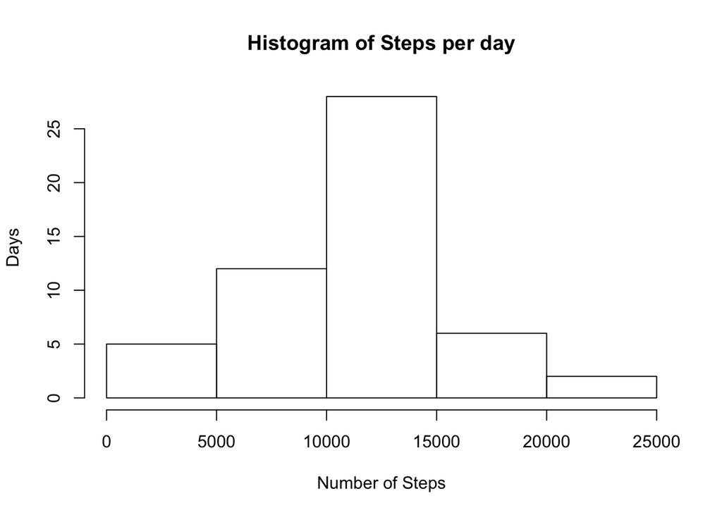

```r
steps_per_day <- aggregate(testing_data_raw$steps, FUN=sum, by=list(testing_data_raw$date))

hist(steps_per_day$x, plot=TRUE, xlab="Number of Steps", ylab="Days", main=paste("Histogram of Steps per day"))
```

We also calculate summary statistics on the steps_per_day object to show the mean and median number of steps taken in a day (just over 10,000):

```r
summary(steps_per_day)
```

```
##        Group.1         x
##  2012-10-01: 1   Min.   :   41
##  2012-10-02: 1   1st Qu.: 8841
##  2012-10-03: 1   Median :10765
##  2012-10-04: 1   Mean   :10766
##  2012-10-05: 1   3rd Qu.:13294
##  2012-10-06: 1   Max.   :21194
##  (Other)   :55   NA's   :8
```

And we need a time series plot of the average number of steps taken. This task is somewhat ambiguous; given that we are asked for a time series plot we will assume that this means a plot of the average number of steps taken across all 5 minute sampling times for each day.

To display this plot we must first average the data using the *aggregate* function:

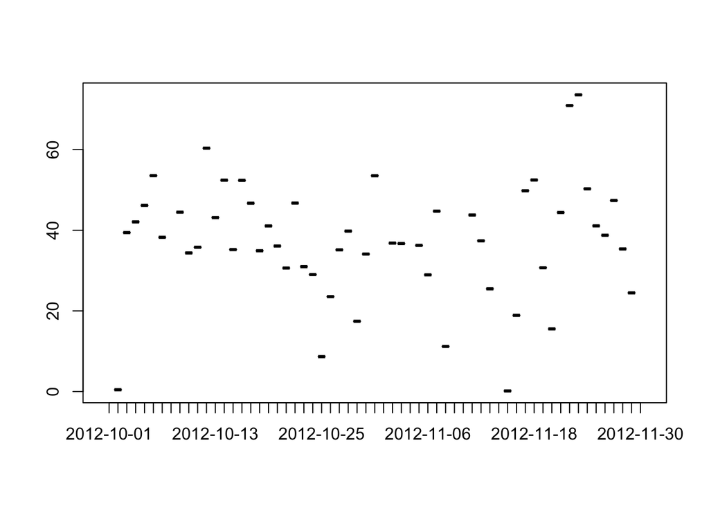

```r
five_minute_avg_steps <- aggregate(testing_data_raw$steps, FUN="mean", by=list(testing_data_raw$date))

plot(five_minute_avg_steps$Group.1, five_minute_avg_steps$x)
```

And a time-series plot *plot.ts* will yeild a plot that shows the days in progression as a dataset:

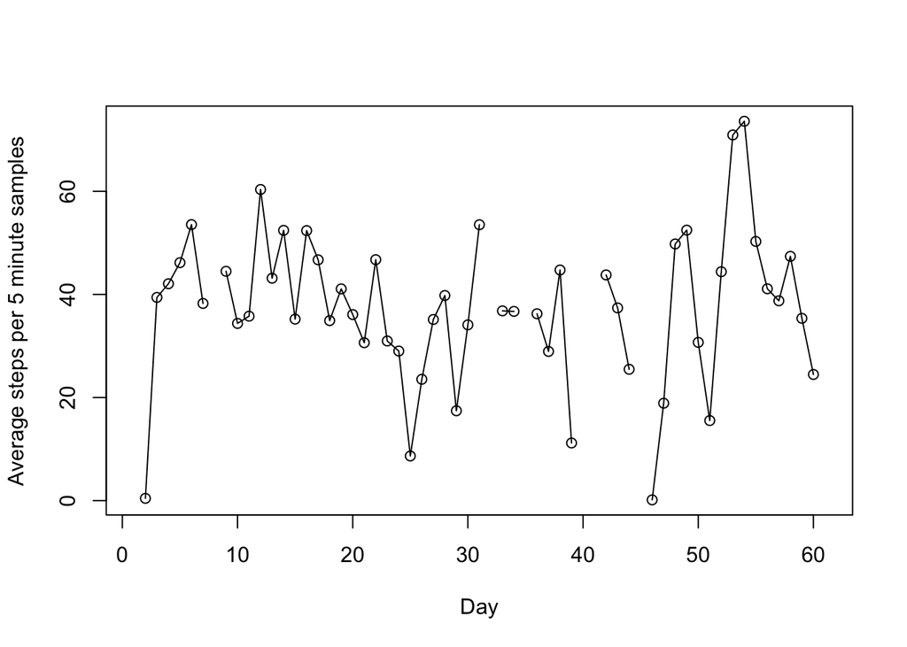

```r
plot.ts(five_minute_avg_steps$Group.1, five_minute_avg_steps$x, xlab="Day", ylab="Average steps per 5 minute samples", xy.labels = FALSE, xy.lines=TRUE)
```

Now we’d like to know which is the busiest (most steps taken) time of the day and therefore, we need to aggregate the data based on the mean of the number of steps in each timeslot over all of the sample days.

We have a lot of NA data in this dataframe and we’ll set it to zero for the time being in order to aggregate by time-slots:

```r
na_removed_data <- testing_data_raw
na_removed_data[is.na(na_removed_data)] <- 0
```

Now we can aggregate the data by the average of the 5 minute time-slots and plot it:

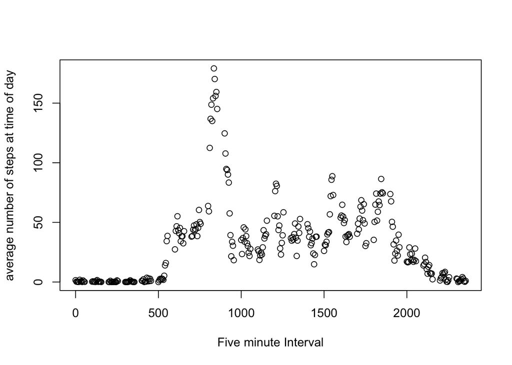

```r
five_minute_avg_per_day <- aggregate(na_removed_data$steps, FUN="mean", by=list(Interval = na_removed_data$interval))

plot(five_minute_avg_per_day$Interval, five_minute_avg_per_day$x, xlab = "Five minute Interval", ylab = "average number of steps at time of day")
```

Finally we can see that the time of day when the subject takes the most steps (on average) is between 5:00 AM and 10:00 AM but we can retrieve the exact interval in time:

```r
five_minute_avg_per_day[which.max(five_minute_avg_per_day$x),]
```

```
##     Interval        x
## 104      835 179.1311
```

So we can see that the time period in which the subject takes the most steps averaged over the 60 days of samples is 8:35 AM during which time he/she takes ~180 steps.